# exercise-05

Sunishka

2/24/2022

Calling libraries

CHALLENGE 1

Using the {tidyverse} read_csv() function, load the “IMDB-movies.csv” dataset from this URL as a “tibble” named d

```r
f <- "https://raw.githubusercontent.com/difiore/ada-2022-datasets/main/IMDB-movies.csv"
d <- read_csv(f, col_names = TRUE)
```

Use a one-line statement to filter the dataset to include just movies from 1920 to 1979 and movies that are between 1 and 3 hours long (runtimeMinutes >= 60 and runtimeMinutes <= 180), and add a new column that codes the startYear into a new variable, decade (“20s,” “30s,” …“70s”). If you do this correctly, there should be 5651 movies remaining in the dataset.

```r
p = d %>%
  filter(startYear %in% 1920:1979) %>%
  filter(runtimeMinutes %in% 60:180) %>%
  mutate(decade = case_when(
    startYear <= 1929 ~ "20s",
    startYear <= 1939 & startYear >= 1930 ~ "30s",
    startYear <= 1949 & startYear >= 1940 ~ "40s",
    startYear <= 1959 & startYear >= 1950 ~ "50s",
    startYear <= 1969 & startYear >= 1960 ~ "60s",
    startYear <= 1979 & startYear >= 1970 ~ "70s"
  ))
```

Use {ggplot2} (which is part of {tidyverse}) to plot histograms of the distribution of runtimeMinutes for each decade.

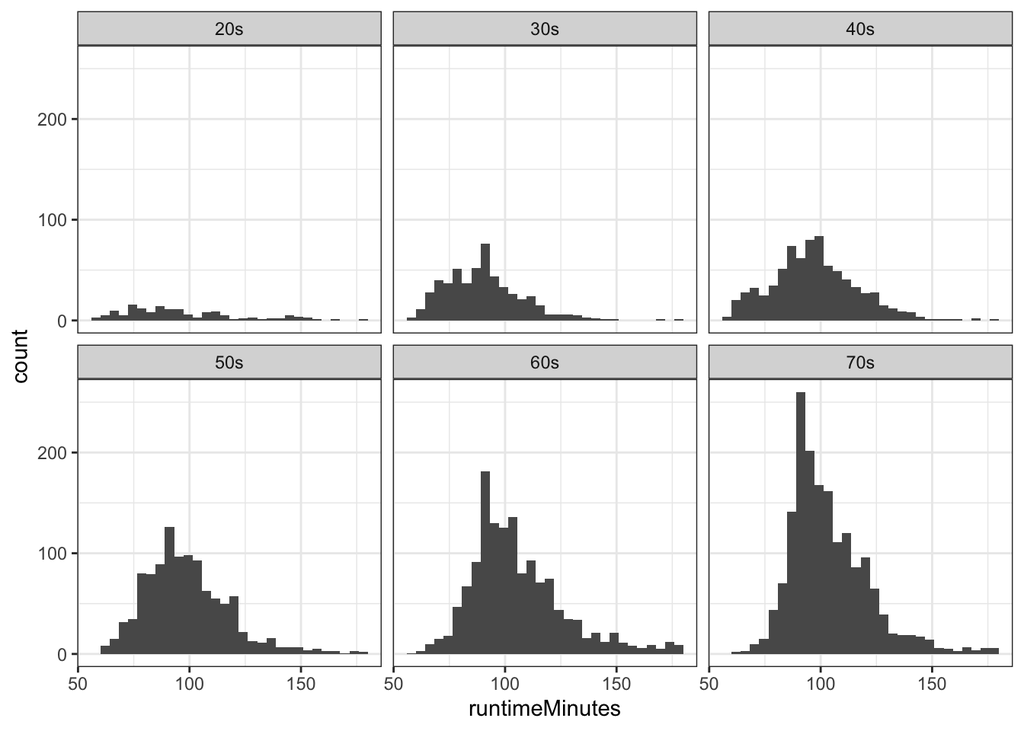

```r
ggplot(p, aes(x=runtimeMinutes))+
  geom_histogram()+
  facet_wrap(~decade)+
  theme_bw()
```

Use a one-line statement to calculate the population mean and population standard deviation in runtimeMinutes for each decade and save the results in a new dataframe called results.

```r
results = p %>%
  group_by(decade) %>%
  summarise(population_mean = mean(runtimeMinutes, na.rm =TRUE),
            population_sd = sd(runtimeMinutes, na.rm = TRUE) )
results
```

```
## # A tibble: 6 × 3
##   decade population_mean population_sd
##   <chr>            <dbl>         <dbl>
## 1 20s               96.3          26.2
## 2 30s               90.3          17.3
## 3 40s               97.2          19.1
## 4 50s               98.9          19.2
## 5 60s              106.           21.2
## 6 70s              104.           18.0
```

Draw a single sample of 100 movies, without replacement, from each decade and calculate the single sample mean and single sample standard deviation in runtimeMinutes for each decades.

```r
random = p %>%
  sample_n(size = 100, replace=FALSE) %>%
  group_by(decade) %>%
  summarise(sample_mean = mean(runtimeMinutes, na.rm = TRUE),
           sample_sd = sd(runtimeMinutes, na.rm = TRUE))
random
```

```
## # A tibble: 6 × 3
##   decade sample_mean sample_sd
##   <chr>        <dbl>     <dbl>
## 1 20s           99        16.1
## 2 30s           89.4      14.1
## 3 40s           89.3      19.9
## 4 50s           94.9      15.4
## 5 60s          104.       20.1
## 6 70s          106.       18.6
```

Calculate for each decade the standard error around your estimate of the population mean runtimeMinutes based on the standard deviation and sample size (n=100 movies) of your single sample.

```r
random = random %>%
  mutate(standard_error = sample_sd/ sqrt(100))
```

Compare these estimates to the actual population mean runtimeMinutes for each decade and to the calculated SE in the population mean for samples of size 100 based on the population standard deviation for each decade.

```r
results
```

```
## # A tibble: 6 × 3
##   decade population_mean population_sd
##   <chr>            <dbl>         <dbl>
## 1 20s               96.3          26.2
## 2 30s               90.3          17.3
## 3 40s               97.2          19.1
## 4 50s               98.9          19.2
## 5 60s              106.           21.2
## 6 70s              104.           18.0
```

```r
random
```

```
## # A tibble: 6 × 4
##   decade sample_mean sample_sd standard_error
##   <chr>        <dbl>     <dbl>          <dbl>
## 1 20s           99        16.1           1.61
## 2 30s           89.4      14.1           1.41
## 3 40s           89.3      19.9           1.99
## 4 50s           94.9      15.4           1.54
## 5 60s          104.       20.1           2.01
## 6 70s          106.       18.6           1.86
```

-I am not sure how to compare these- some sort of stats? -However, just by looking at them I can tell they are quite similar.

Generate a sampling distribution of mean runtimeMinutes for each decade by [a] drawing 1000 samples of 100 movies from each decade and, for each sample, [b] calculating the mean runtimeMinutes and the standard deviation in runtimeMinutes for each decade.

```r
reps = 1000

sampling_dist = do(reps) * (p %>%
  group_by(decade) %>%
  slice_sample(n=100, replace = FALSE))

sampling_dist_mean_sd = sampling_dist %>%
  group_by(.index, decade) %>%
  summarise(samp_dist_mean=mean(runtimeMinutes),
    samp_dist_se=sd(runtimeMinutes))
```

Then, calculate the mean and the standard deviation of the sampling distribution of sample means for each decade (the former should be a very good estimate of the population mean, while the latter is another estimate of the standard error in our estimate of the population mean for a particular sample size) and plot a histogram of the sampling distribution for each decade. What shape does it have?

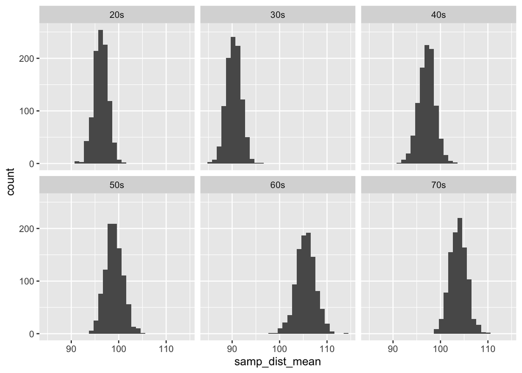

```r
sample_means = sampling_dist_mean_sd %>%
  group_by(decade) %>%
  summarise(sample_mean = mean(samp_dist_mean),
            sample_mean_sd = sd(samp_dist_mean))

ggplot(sampling_dist_mean_sd, aes(x = samp_dist_mean)) +
  geom_histogram() +
  facet_wrap(~decade)
```

These are all normal distributions

Finally, compare the standard error in runtimeMinutes for samples of size 100 from each decade [1] as estimated from your first sample of 100 movies, [2] as calculated from the known population standard deviations for each decade, and [3] as estimated from the sampling distribution of sample means for each decade.

```r
standard_errors_1 = sampling_dist_mean_sd %>%
  filter(.index == 1) %>%
  mutate(SE = samp_dist_se/sqrt(100))

standard_errors_2 = p %>%
  group_by(decade) %>%
  summarise(n = n(),
            sd_runtimeMinutes = sd(runtimeMinutes),
            SE = sd_runtimeMinutes/sqrt(n))


standard_errors_3 = sample_means %>%
  mutate(SE = sample_mean_sd/sqrt(1000))
```

CHALLENGE 2

Using the {tidyverse} read_csv() function, load the “zombies.csv” dataset from this URL as a “tibble” named z.

```r
g <- "https://raw.githubusercontent.com/difiore/ada-2022-datasets/main/zombies.csv"
z <- read_csv(g, col_names = TRUE)
```

Calculate the population mean and standard deviation for each quantitative random variable in the dataset (height, weight, age, number of zombies killed, and years of education).

```r
z_means = c(mean(z$height), mean(z$weight), mean(z$age),
            mean(z$zombies_killed), mean(z$years_of_education))

tibble("variable" = colnames(z))
```

```
## # A tibble: 10 × 1
##    variable
##    <chr>
##  1 id
##  2 first_name
##  3 last_name
##  4 gender
##  5 height
##  6 weight
##  7 zombies_killed
##  8 years_of_education
##  9 major
## 10 age
```

```r
pop_sd = function(variable){
  sq_dev = (variable - mean(variable))^2
  sd = sqrt(sum(sq_dev)/length(sq_dev))
  sd
}
z_mean_sd = z %>%
  summarise(mean_height = mean(height),
         pop_sd_height = pop_sd(height),
         mean_weight = mean(weight),
         pop_sd_weight = pop_sd(weight),
         mean_age = mean(age),
         pop_sd_age = pop_sd(age),
         mean_zombies_killed = mean(zombies_killed),
         pop_sd_zombies_killed = pop_sd(zombies_killed),
         mean_yo_education = mean(years_of_education),
         pop_sd_yo_education = pop_sd(years_of_education))
```

Use {ggplot} and make boxplots of each of these variables by gender.

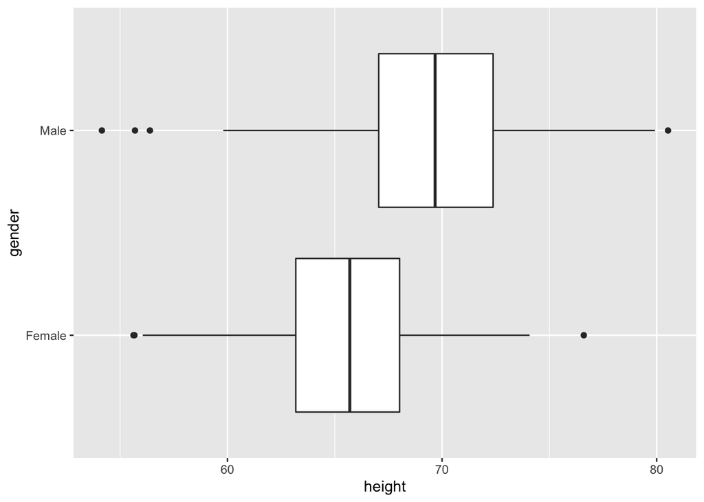

```r
ggplot(z, aes(height, gender))+
  geom_boxplot()
```

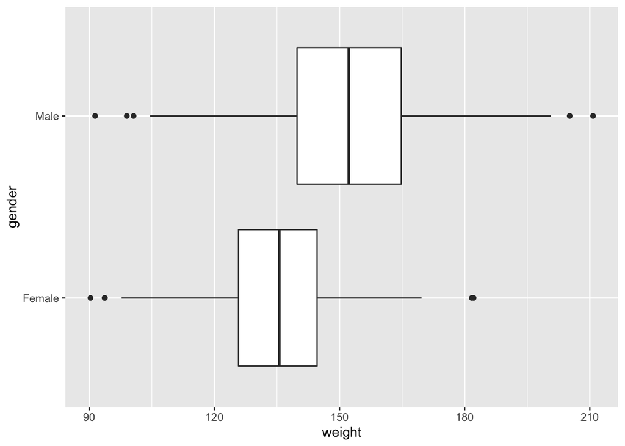

```r
ggplot(z, aes(weight, gender))+
  geom_boxplot()
```

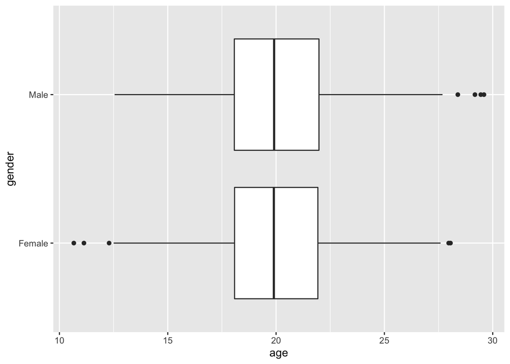

```r
ggplot(z, aes(age, gender))+
  geom_boxplot()
```

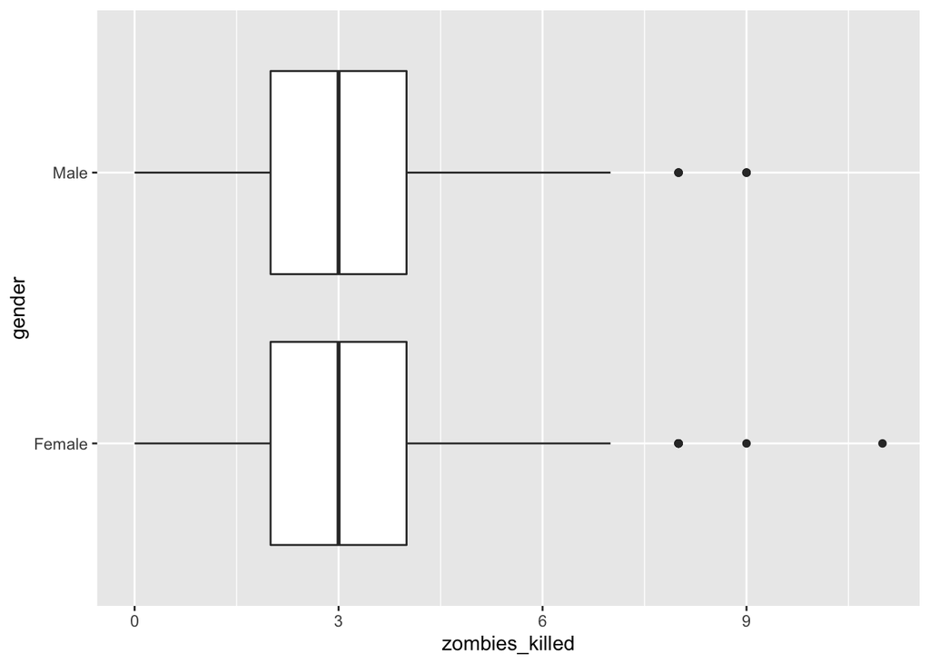

```r
ggplot(z, aes(zombies_killed, gender))+
  geom_boxplot()
```

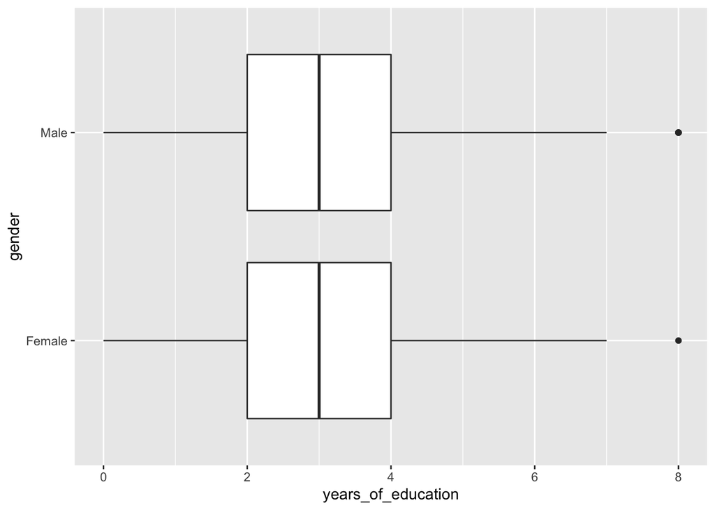

```r
ggplot(z, aes(years_of_education, gender))+
  geom_boxplot()
```

Use {ggplot} and make scatterplots of height and weight in relation to age (i.e., use age as the x variable), using different colored points for males versus females. Do these variables seem to be related? In what way?

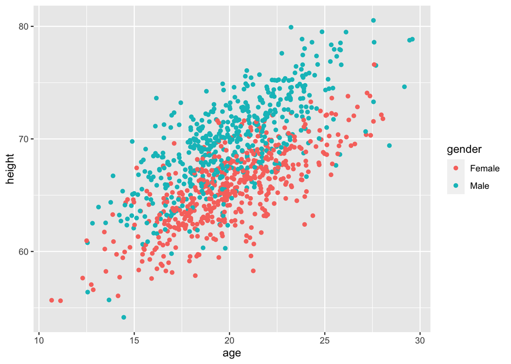

```r
z_height_weight = z %>%
  select(age, height, weight)

ggplot(z)+
  geom_point(aes(age, height, color = gender))
```

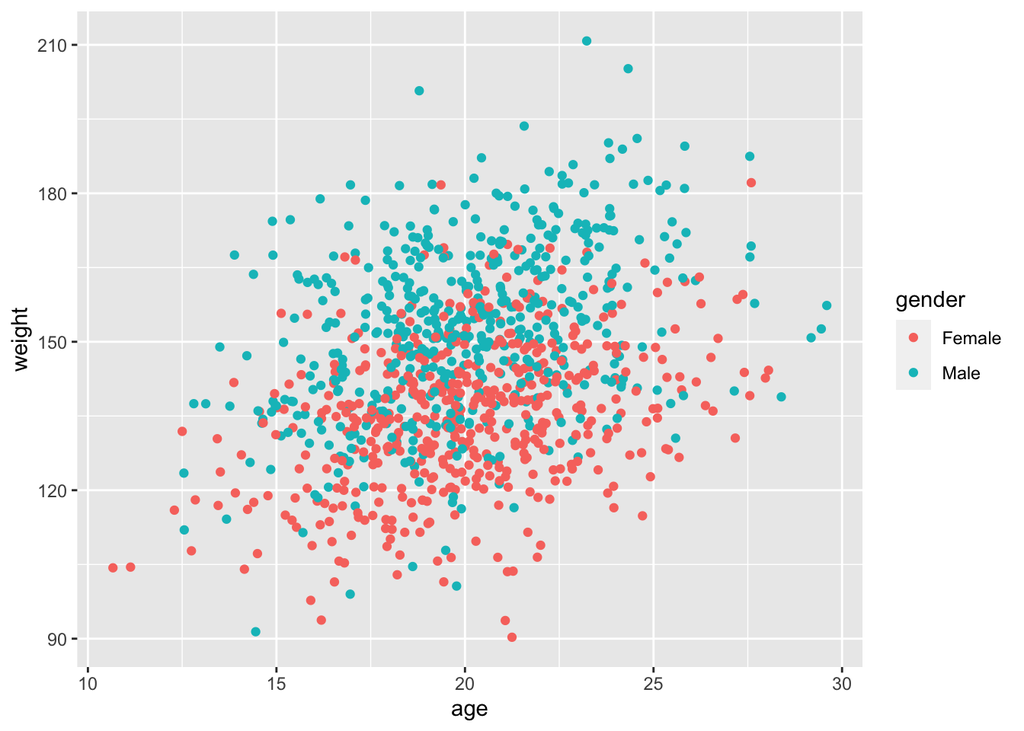

```r
ggplot(z)+
  geom_point(aes(age, weight, color = gender))
```

Older people seem to be taller, however the scatter for weight is too much to make a conclusive statement.

Using histograms and Q-Q plots, check whether each of the quantitative variables seem to be drawn from a normal distribution. Which seem to be and which do not?

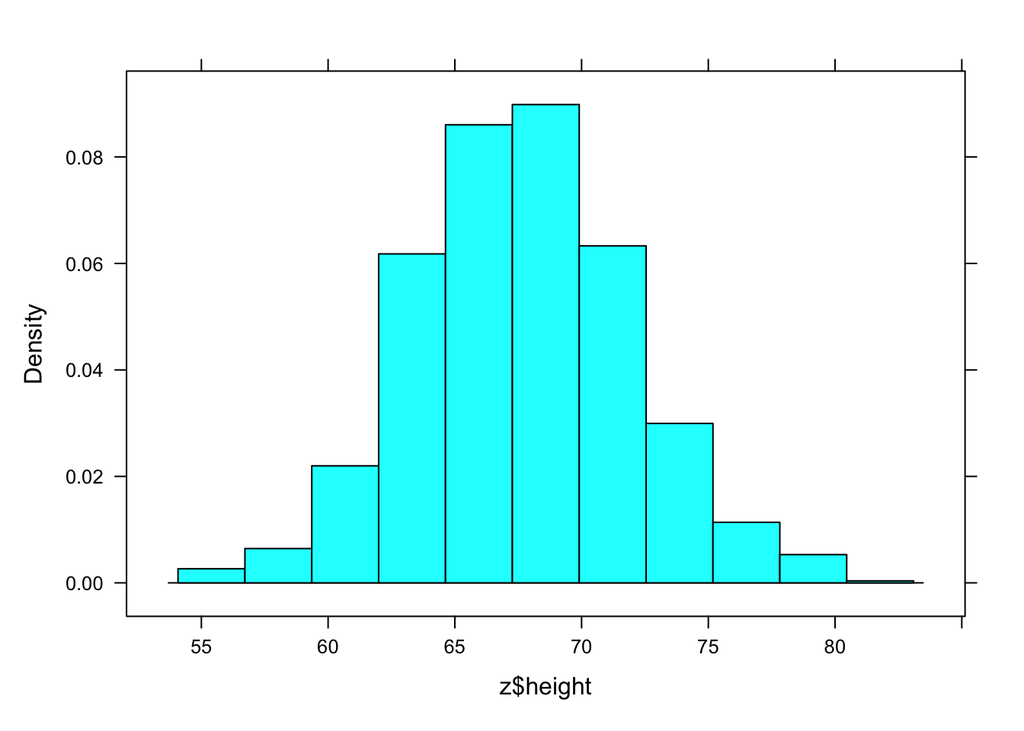

```r
#height
histogram(z$height)
```

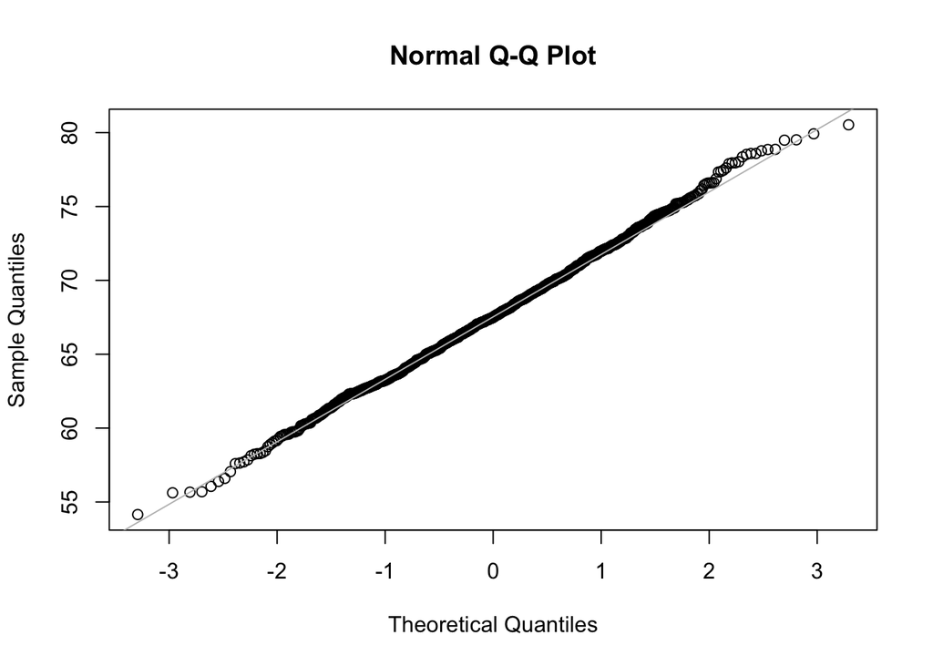

```r
qqnorm(z$height)
qqline(z$height, col = "gray")
```

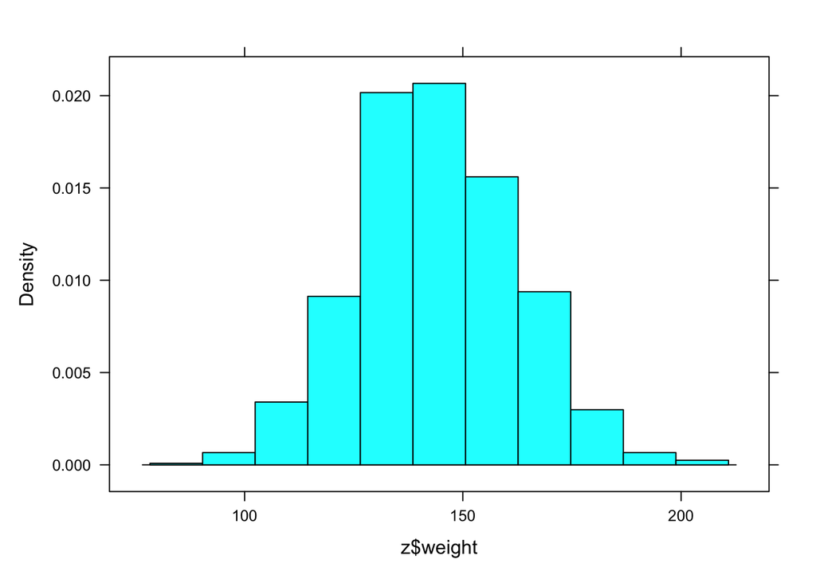

```r
#weight
histogram(z$weight)
```

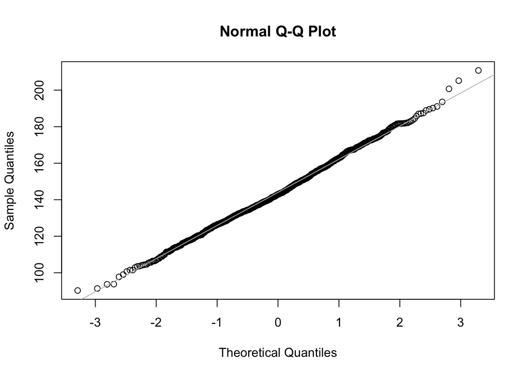

```r
qqnorm(z$weight)
qqline(z$weight, col = "gray")
```

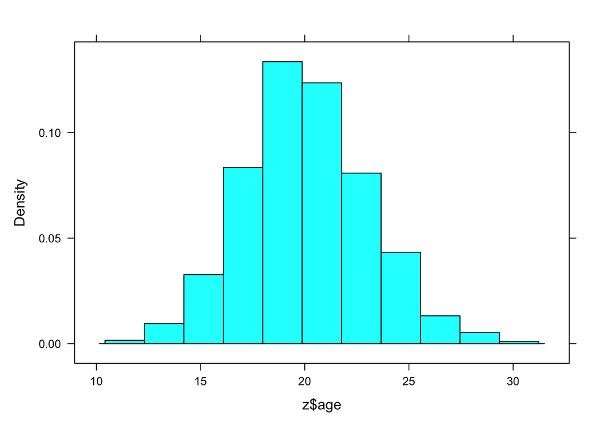

```r
#age
histogram(z$age)
```

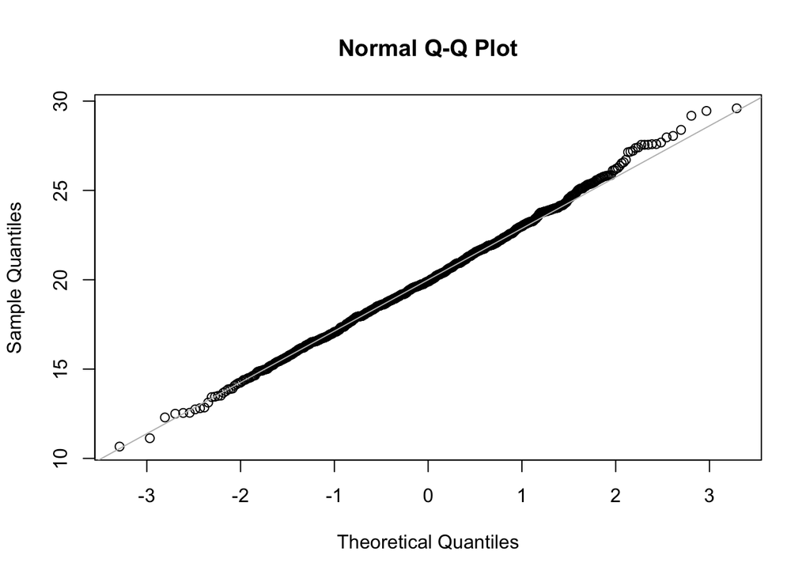

```r
qqnorm(z$age)
qqline(z$age, col = "gray")
```

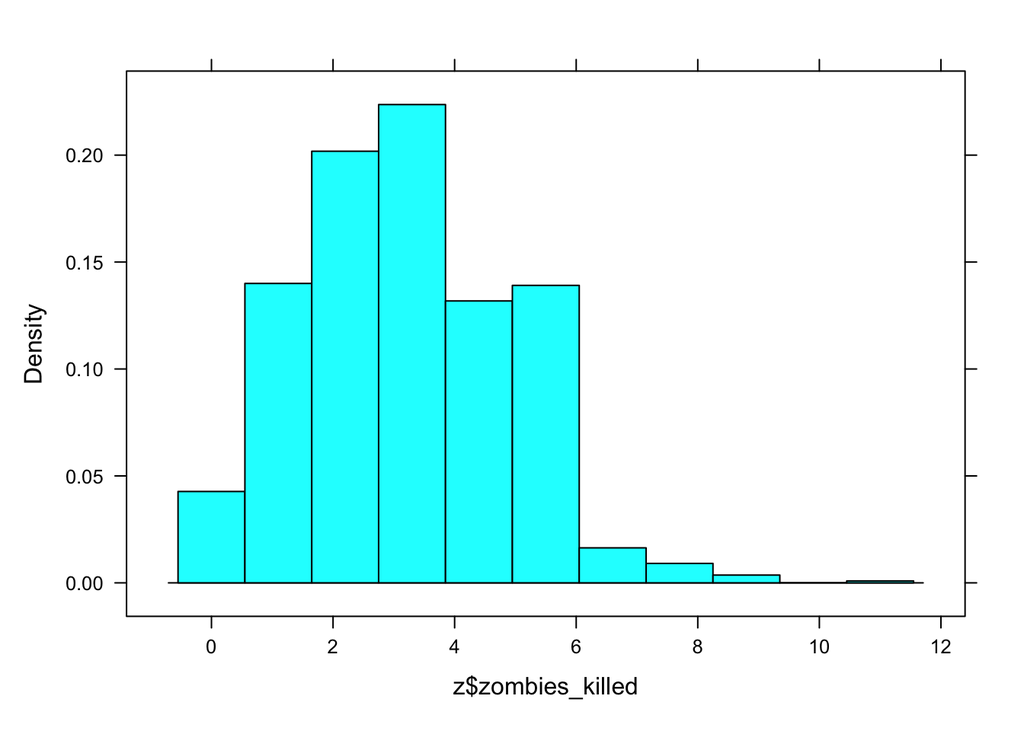

```r
#zombies killed
histogram(z$zombies_killed)
```